# Reproducible Research: Peer Assessment 1

## Loading and preprocessing the data

At first we read the data file.

```r
activity<-read.csv("./activity.csv", na.strings="NA")
```

## What is mean total number of steps taken per day?

To calculate average number of steps taken per day we use a new variable with aggregate number of steps per day.

```r
steps.per.day <- aggregate(steps ~ date, data = activity, sum)
avg.steps.with.na <- mean(steps.per.day$steps, na.omit = TRUE)
median.steps.with.na <- median(steps.per.day$steps, na.rm = TRUE)
```

1. Here you can see a histogram of the total number of steps taken each day.

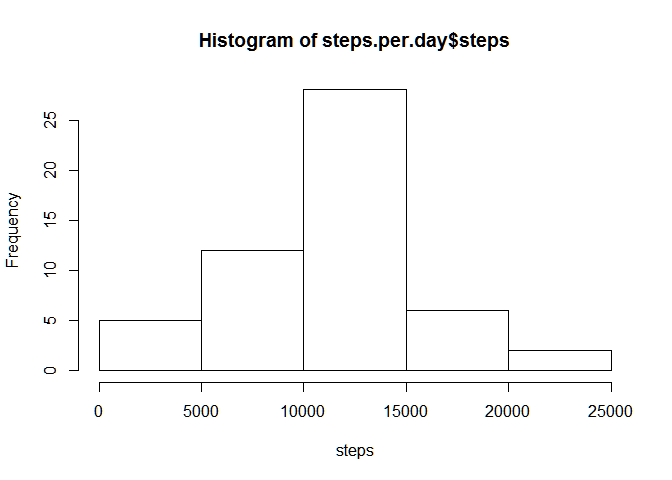

```r
hist(steps.per.day$steps, xlab = "steps")
```

2. The average number of steps per day is equal 10766.2, median is equal 10765.

## What is the average daily activity pattern?

1. To calculate average number of steps taken, averaged across all days, we used aggregate function. The following plot demonstrates the average daily activity pattern.

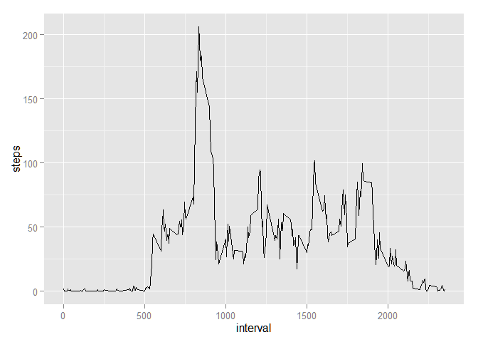

```r
library(ggplot2)
daily.pattern <- aggregate(steps ~ interval, data = activity, mean)
qplot(interval, steps, data = daily.pattern, geom="path")
```

2. The maximum number of steps were made in the 835th 5-minute interval.

## Imputing missing values

1. Calculating the number of NA values.

```r
na.num <- sum(is.na(activity$steps))
```

The total number of missing values in the activity dataset is equal 2304.

2. We used mean for appropriate 5-minute interval to replace missing values.
3. New dataset (activity.imp) was created with imputed missing values.

```r
library(plyr)
activity.imp <- merge(activity, daily.pattern, by.x="interval", by.y="interval")
names(activity.imp)<-c("interval", "steps", "date", "avg.5min")
for(i in 1:nrow(activity.imp)) {
  if(is.na(activity.imp$steps[i])) activity.imp$steps[i] <- activity.imp$avg.5min[i]
}
```

4. Here you can see a histogram of the total number of steps taken each day (after imputing missing values).

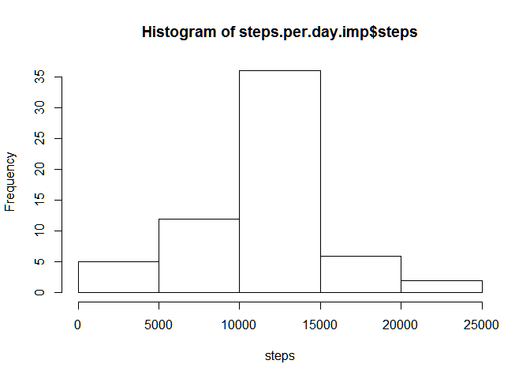

```r
steps.per.day.imp <- aggregate(steps ~ date, data = activity.imp, sum)
avg.steps.without.na <- mean(steps.per.day.imp$steps, na.omit = TRUE)
median.steps.without.na <- median(steps.per.day.imp$steps, na.rm = TRUE)
hist(steps.per.day.imp$steps, xlab = "steps")
```

The average number of steps per day (after imputing missing values) is equal 10766.2, median is equal 10766.2.

The median of new dataset is different from the original one and is equal to the mean value. The mean value doesn’t change.

After imputing missing data the total daily number of steps increased a little bit.

## Are there differences in activity patterns between weekdays and weekends?

```r
  loc <- Sys.getlocale("LC_TIME")
  newloc<-Sys.setlocale("LC_TIME", locale="English")
  d <- as.Date(activity.imp$date, tz="GMT")
  activity.imp$wd <- weekdays(d)
  activity.imp$wdf <- factor(as.numeric(activity.imp$wd == "Sunday" | activity.imp$wd == "Saturday"), labels = c("weekend", "weekday"))
  loc <- Sys.setlocale("LC_TIME", locale = loc)
```

2. The following diagram demonstrates the differences in activity patterns between weekdays and weekends.

[figure not shown]

```r
  avg.wd <- aggregate(steps ~ interval + wdf, data = activity.imp, mean)
  qplot(interval, steps, data = avg.wd, facets = wdf ~ ., geom = "path")
```